# NLP_Project_Full_Code-JRW

## **Loading the dataset**

```python
# # uncomment and run the following code if Google Colab is being used and the dataset is in Google Drive
from google.colab import drive
drive.mount('/content/drive')
```

```python
# Load the image file of dataset
file_path = '/content/drive/My Drive/ColabNotebooks/stock_news.csv'
stock_news = pd.read_csv(file_path)
```

```python
#Creating a copy of the dataset
stock = stock_news.copy()
```

## **Data Overview**

### Displaying the first few rows of the dataset

```python
stock.head()
```

|  | Date | News | Open | High | Low | Close | Volume | Label |
| --- | --- | --- | --- | --- | --- | --- | --- | --- |
| 0 | 2019-01-02 | The tech sector experienced a significant dec... | 41.740002 | 42.244999 | 41.482498 | 40.246914 | 130672400 | -1 |
| 1 | 2019-01-02 | Apple lowered its fiscal Q1 revenue guidance ... | 41.740002 | 42.244999 | 41.482498 | 40.246914 | 130672400 | -1 |
| 2 | 2019-01-02 | Apple cut its fiscal first quarter revenue fo... | 41.740002 | 42.244999 | 41.482498 | 40.246914 | 130672400 | -1 |
| 3 | 2019-01-02 | This news article reports that yields on long... | 41.740002 | 42.244999 | 41.482498 | 40.246914 | 130672400 | -1 |
| 4 | 2019-01-02 | Apple's revenue warning led to a decline in U... | 41.740002 | 42.244999 | 41.482498 | 40.246914 | 130672400 | -1 |

### Understanding the shape of the dataset

```python
stock.shape
```

```
(349, 8)
```

### Checking the data types of the columns

```python
stock.info()
```

```
<class 'pandas.core.frame.DataFrame'>
RangeIndex: 349 entries, 0 to 348
Data columns (total 8 columns):
 #   Column  Non-Null Count  Dtype
---  ------  --------------  -----
 0   Date    349 non-null    object
 1   News    349 non-null    object
 2   Open    349 non-null    float64
 3   High    349 non-null    float64
 4   Low     349 non-null    float64
 5   Close   349 non-null    float64
 6   Volume  349 non-null    int64
 7   Label   349 non-null    int64
dtypes: float64(4), int64(2), object(2)
memory usage: 21.9+ KB
```

```python
stock['Date'] = pd.to_datetime(stock['Date'])  # to convert the 'Date' column in the 'stock' DataFrame to datetime format.
stock.tail()
```

|  | Date | News | Open | High | Low | Close | Volume | Label |
| --- | --- | --- | --- | --- | --- | --- | --- | --- |
| 344 | 2019-04-30 | Media mogul Oprah Winfrey, known for influenc... | 50.764999 | 50.849998 | 49.7775 | 48.70879 | 186139600 | -1 |
| 345 | 2019-04-30 | European shares fell on Tuesday, with banks u... | 50.764999 | 50.849998 | 49.7775 | 48.70879 | 186139600 | -1 |
| 346 | 2019-04-30 | This article reports that the S&P 500 reached... | 50.764999 | 50.849998 | 49.7775 | 48.70879 | 186139600 | -1 |
| 347 | 2019-04-30 | The Federal Reserve is anticipated to keep in... | 50.764999 | 50.849998 | 49.7775 | 48.70879 | 186139600 | -1 |
| 348 | 2019-04-30 | In the first quarter, South Korea's Samsung E... | 50.764999 | 50.849998 | 49.7775 | 48.70879 | 186139600 | 0 |

### Checking the statistical summary

```python
stock.describe()
```

|  | Date | Open | High | Low | Close | Volume | Label |
| --- | --- | --- | --- | --- | --- | --- | --- |
| count | 349 | 349.000000 | 349.000000 | 349.000000 | 349.000000 | 3.490000e+02 | 349.000000 |
| mean | 2019-02-16 16:05:30.085959936 | 46.229233 | 46.700458 | 45.745394 | 44.926317 | 1.289482e+08 | -0.054441 |
| min | 2019-01-02 00:00:00 | 37.567501 | 37.817501 | 37.305000 | 36.254131 | 4.544800e+07 | -1.000000 |
| 25% | 2019-01-14 00:00:00 | 41.740002 | 42.244999 | 41.482498 | 40.246914 | 1.032720e+08 | -1.000000 |
| 50% | 2019-02-05 00:00:00 | 45.974998 | 46.025002 | 45.639999 | 44.596924 | 1.156272e+08 | 0.000000 |
| 75% | 2019-03-22 00:00:00 | 50.707500 | 50.849998 | 49.777500 | 49.110790 | 1.511252e+08 | 0.000000 |
| max | 2019-04-30 00:00:00 | 66.817497 | 67.062500 | 65.862503 | 64.805229 | 2.444392e+08 | 1.000000 |
| std | NaN | 6.442817 | 6.507321 | 6.391976 | 6.398338 | 4.317031e+07 | 0.715119 |

### Checking the duplicate values

```python
print("Number of Duplicated Values in the stock variable is", stock.duplicated().sum(),'\n'*5)
stock.duplicated().sum()
```

```
Number of Duplicated Values in the stock variable is 0
```

```
0
```

### Checking for missing values

```python
stock.isnull().sum()
```

|  | 0 |
| --- | --- |
| Date | 0 |
| News | 0 |
| Open | 0 |
| High | 0 |
| Low | 0 |
| Close | 0 |
| Volume | 0 |
| Label | 0 |

**dtype:** int64

### Checking for Unique Values

```python
print(stock.nunique())
```

```
Date       71
News      349
Open       70
High       70
Low        71
Close      71
Volume     71
Label       3
dtype: int64
```

## **Exploratory Data Analysis**

### Univariate Analysis

- Distribution of individual variables
- Compute and check the distribution of the length of news content

#### Observations on Label

| Label | proportion |
| --- | --- |
| 0 | 0.487106 |
| -1 | 0.283668 |
| 1 | 0.229226 |

**dtype:** float64

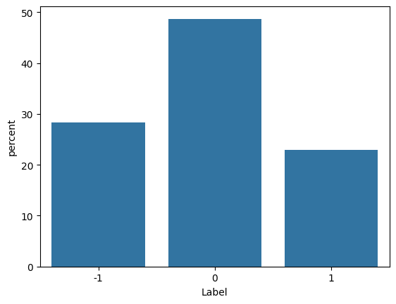

```python
sns.countplot(data=stock, x="Label", stat="percent");
stock['Label'].value_counts(normalize=True)
```

#### Observations on Price (Open,High,Low,Close)

|  | Open | High | Low | Close |
| --- | --- | --- | --- | --- |
| count | 349.000000 | 349.000000 | 349.000000 | 349.000000 |
| mean | 46.229233 | 46.700458 | 45.745394 | 44.926317 |
| std | 6.442817 | 6.507321 | 6.391976 | 6.398338 |
| min | 37.567501 | 37.817501 | 37.305000 | 36.254131 |
| 25% | 41.740002 | 42.244999 | 41.482498 | 40.246914 |
| 50% | 45.974998 | 46.025002 | 45.639999 | 44.596924 |
| 75% | 50.707500 | 50.849998 | 49.777500 | 49.110790 |
| max | 66.817497 | 67.062500 | 65.862503 | 64.805229 |

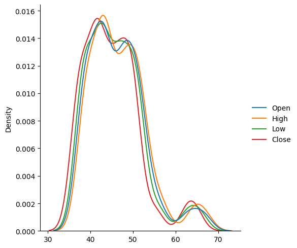

```python
sns.displot(data=stock[['Open','High','Low','Close']], kind="kde", palette="tab10");
prices = stock[['Open','High','Low','Close']]
prices.describe()
```

#### Observations on Volume

|  | Volume |
| --- | --- |
| count | 3.490000e+02 |
| mean | 1.289482e+08 |
| std | 4.317031e+07 |
| min | 4.544800e+07 |
| 25% | 1.032720e+08 |
| 50% | 1.156272e+08 |
| 75% | 1.511252e+08 |
| max | 2.444392e+08 |

**dtype:** float64

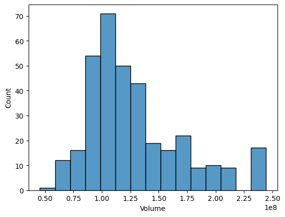

```python
sns.histplot(data=stock, x='Volume');
stock['Volume'].describe()
```

#### Observations on News length

- The average news article length is 49-50 words
- The min is 19 words and the max is 61 words
- The vast majority of news articles are clustered between 40 to 60 words per the histplot
- There are minimal outliers located below 40 words

```
count    349.000000
mean      49.312321
std        5.727770
min       19.000000
25%       46.000000
50%       50.000000
75%       53.000000
max       61.000000
Name: News_Length, dtype: float64
```

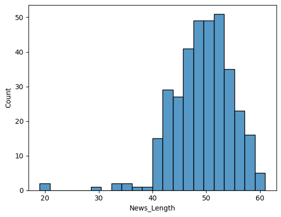

```python
#Calculating the total number of words present in the news content.
stock['News_Length'] = stock['News'].apply(lambda x: len(x.split(' ')))
print(stock['News_Length'].describe())
sns.histplot(data=stock, x="News_Length");
```

### Bivariate Analysis

- Correlation
- Sentiment Polarity (Label) vs Price
- Sentiment Polarity (Label) vs Volume
- Date vs Price
- Volume vs Close Price

#### Correlation

Observations:

- The correlation for the pricing to each other is all 1, meaning the pricing is all dependant on each other, which makes complete sense
- The correlation for Volume, Label, and News Length to each other or any other pricing value is insignificant, +/- 0.1, with low of -0.1 and high of 0.1

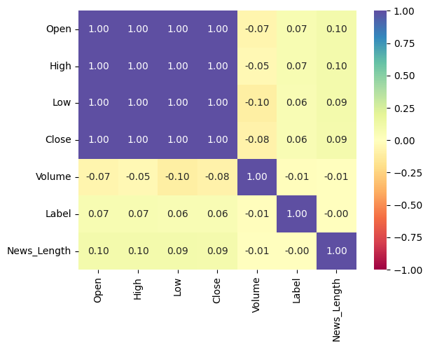

```python
sns.heatmap(
    stock[["Open","High","Low","Close", "Volume", "Label", "News_Length"]].corr(), annot=True, vmin=-1, vmax=1, fmt=".2f", cmap="Spectral"
);
```

#### Label vs Price (Open, High, Low, Close)

Observations:

- Open and Low Pricing boxplots when taking into account label, are very simialr to each other; wider range of pricing for neutral and positive labels, smaller range for negative labels, inclusive of min, max, average and outliers.
- High and Close Pricing boxplots when taking into account label, are very simialr to each other; very similar range of pricing for negative, neutral and positive labels, inclusive of min, max, average and outliers.

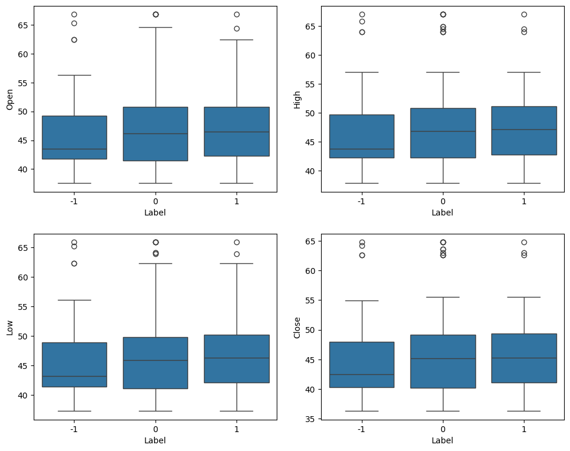

```python
plt.figure(figsize=(10, 8))

for i, variable in enumerate(['Open', 'High', 'Low', 'Close']):
    plt.subplot(2, 2, i + 1)
    sns.boxplot(data=stock, x="Label", y=variable)
    plt.tight_layout(pad=2)

plt.show()
```

#### Label vs Volume

Observations:

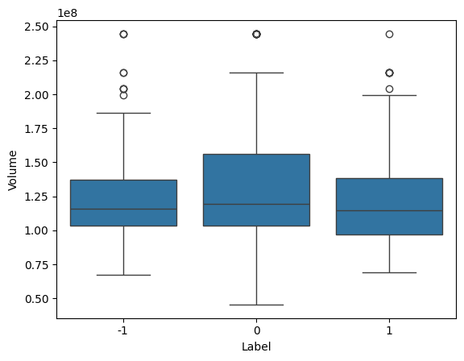

```python
sns.boxplot(data=stock, x="Label", y="Volume");
```